# 2.3.1 LNCaP LOY vs sgCTRL — RNA-seq base analysis

# Overview

LNCaP **LOY vs sgCTRL** RNA-seq analysis (MAY 2026 batch — processed with the standardized STAR two-pass + featureCounts v2.1.1 / GENCODE v49 pipeline). LNCaP is an androgen-dependent prostate adenocarcinoma line carrying an **AR T878A** ligand-binding-domain mutation, biallelic **PTEN deletion** (constitutive PI3K/AKT activation), and wild-type **TP53**. LOY was generated by transient nucleofection of a Y-chromosome-targeting sgRNA; sgCTRL is the matched non-targeting sgRNA control. **No PARENTAL arm** was collected for LNCaP — the experiment is a balanced three-passage paired sgCTRL-vs-LOY block.

**Design.** Three biological passages (P12, P13, P14) per arm were grown in parallel and sequenced in the same batch. The DE model includes passage as a paired block (`~ 0 + treatment + passage`) so per-passage drift is removed before testing. The contrast is strictly `LOY − CTRL`.

Every figure is saved to `figures_LOY_sgCTRL/` as both PNG (for iterative review) and PDF (for publication).

**Counts pipeline.** Counts come from `STAR_v2_PARfix/MAY_2026_LNCAP_LOY/` — a PAR-Y-masked STAR realignment + featureCounts re-quantification done specifically to recover chrX-PAR reads that the original MAY_2026 STAR run silently dropped at multi-mapper filtering. MSY (true chrY) counts are unchanged; PAR1/PAR2 counts (SHOX, CSF2RA, SLC25A6, etc.) are now non-zero. Y-region annotation lives in §2.1.5; the Y/PAR-retaining volcano is §3.5.

| Group | Samples | Y Status | Role |
| --- | --- | --- | --- |
| CTRL | 3 (P12, P13, P14) | Y+ | sgRNA control (reference for the LOY-vs-sgCTRL contrast) |
| LOY | 3 (P12, P13, P14) | Y− | Y chromosome deleted |

# 1. Setup

## 1.1 Load Packages

## 1.2 Paths, Parameters, and PNG-First Figure Helper

## 1.3 Auto-generate Sample Metadata from Filenames

LNCaP Sample Summary

| treatment | n | replicates | y_status |
| --- | --- | --- | --- |
| CTRL | 3 | 12, 13, 14 | Y+ |
| LOY | 3 | 12, 13, 14 | Y- |

## 1.4 Load Count Data

```
## Loading 6 LNCaP count files from
##    A:/Dropbox/LOY_paralogs/projects/RNAseq/counts/STAR_v2_PARfix/MAY_2026_LNCAP_LOY
```

```
## Loaded 78899 genes across 6 samples
```

# 2. QC: DGEList, Filter, TMM

## 2.1 Build DGEList (2-level treatment factor)

```
## Removing 54543 genes without full annotation
```

```
## Genes remaining: 24356
```

## 2.1.5 Y-region annotation (PAR1 / PAR2 / MSY-Yp / MSY-Yq)

GRCh38 PAR coordinates (Ensembl/GENCODE). PAR genes are annotated on chrX only (chrY PAR positions are masked at the annotation level), so PAR identification scans chrX. MSY = remaining chrY genes (non-PAR), split into Yp / Yq by the chrY centromere midpoint (~10.43 Mb, UCSC).

Two filter sets are exposed downstream:

- **`chrY_gene_ids`** (MSY only) is stripped from the DGEList before differential expression. PAR genes stay in `dge_lc` so they get logFC + FDR values like any other gene — useful for the §3.5 Y-region volcano and for §11-style per-gene PAR summaries.
- **`excluded_gene_ids`** (chrY ∪ PAR) is stripped from pathway-analysis inputs (fgsea ranks, camera, decoupleR ULM, DoRothEA, GSVA / ssGSEA, PROGENy, msVIPER). PAR contamination of those ranks is library-composition artefact (LOY samples lose the chrY-PAR copy), not pathway biology. Filtering happens inside `prep_ranks_t()` (which then cascades to every fgsea-derived pathway call) plus at each gene-symbol-keyed matrix-input call site (decoupleR / GSVA / PROGENy).

```
## Y-region panel: 113 genes  [PAR1=20, PAR2=3, MSY-Yp=35, MSY-Yq=55]
```

```
## Exclusion set for pathway analyses: 113 genes (chrY ∪ PAR)
```

## 2.2 Filter Low-Expressed Genes

```
## Before filtering: 24356
```

```
## After filtering:  13399
```

## 2.3 TMM Normalization

Library sizes and normalization factors

|  | treatment | passage | lib.size | norm.factors | lib.size_M | effective_lib |
| --- | --- | --- | --- | --- | --- | --- |
| LNCaP-LOY-P12 | LOY | 12 | 53823946 | 1.0159361 | 53.8 | 54.7 |
| LNCaP-LOY-P13 | LOY | 13 | 46146504 | 1.0246689 | 46.1 | 47.3 |
| LNCaP-LOY-P14 | LOY | 14 | 45562261 | 0.9864658 | 45.6 | 44.9 |
| LNCaP-sgCTRL-P12 | CTRL | 12 | 55510920 | 1.0085847 | 55.5 | 56.0 |
| LNCaP-sgCTRL-P13 | CTRL | 13 | 53302620 | 1.0246291 | 53.3 | 54.6 |
| LNCaP-sgCTRL-P14 | CTRL | 14 | 36116430 | 0.9422995 | 36.1 | 34.0 |

## 2.4 PCA

### PC1 vs PC2

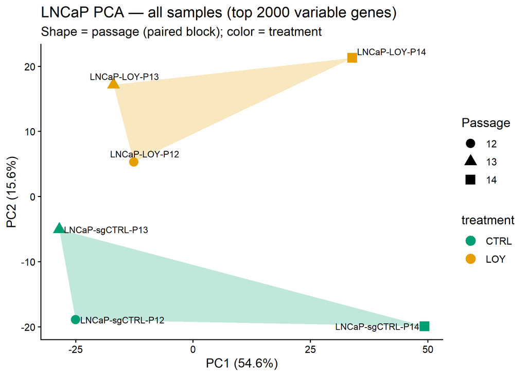

```
## Saved: pca_pc1_pc2.(png|pdf)  [7x5 in]
```

### PC1 vs PC3

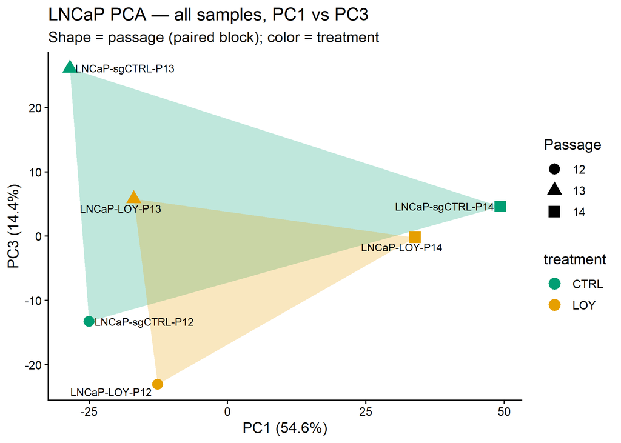

```
## Saved: pca_pc1_pc3.(png|pdf)  [7x5 in]
```

## 2.5 Sample distance heatmap

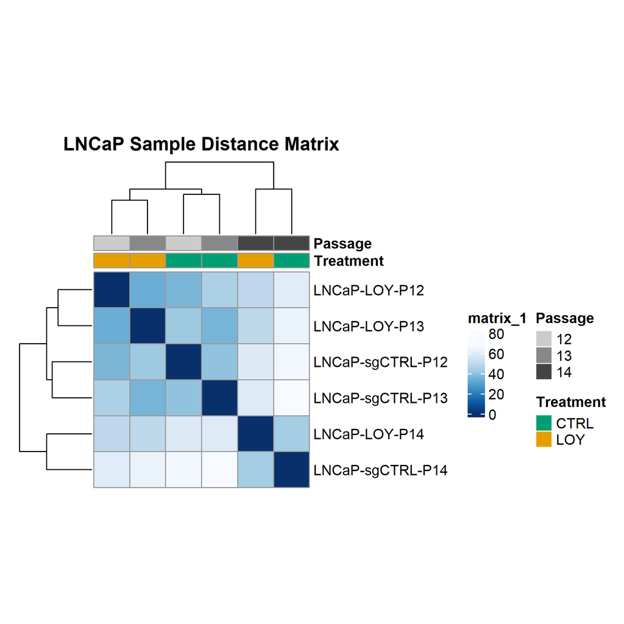

# 3. Y Chromosome Expression

Sanity check: LOY samples should show markedly lower expression of Y-chromosome protein-coding genes than sgCTRL.

```
## Y chromosome genes in data: 7 / 53
```

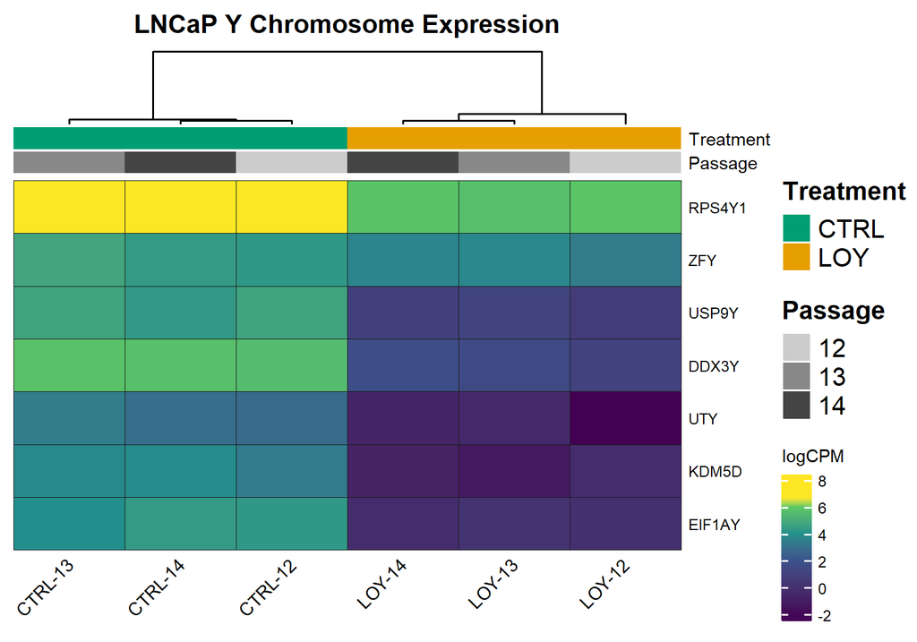

## 3.2 Per-sample summary + key paralogs

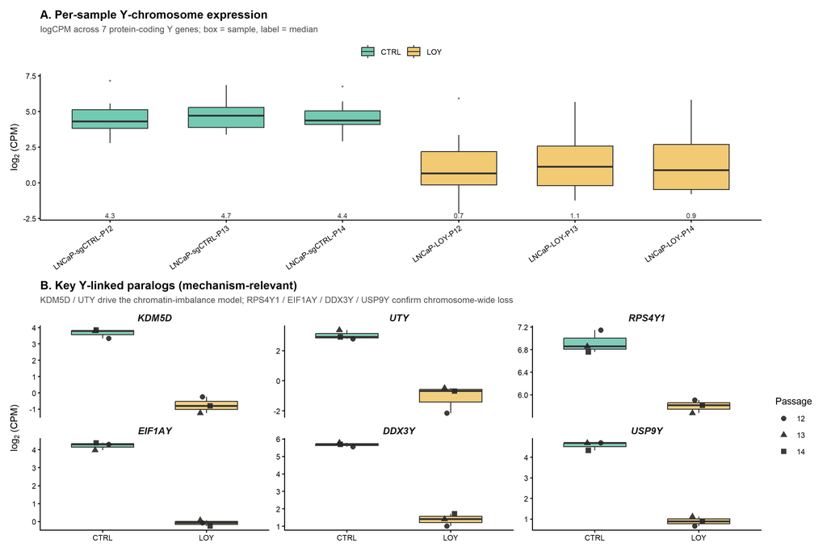

```
## Saved: y_chromosome_summary_and_paralogs.(png|pdf)  [12x8 in]
```

# 3.5 Y-region volcano (pre-strip)

A LOY-vs-sgCTRL paired DE run on a **Y-retaining and PAR-retaining** working set. Every chrY (MSY-Yp / MSY-Yq) and chrX-PAR (PAR1 / PAR2) gene that passes filterByExpr appears here with a real `logFC` + `FDR` value — so the volcano shows exactly *what* the LOY perturbation does to the Y-linked + PAR expression landscape before §4 strips those genes for pathway analysis.

This view was previously impossible because the upstream STAR pipeline dropped PAR multi-mappers (all PAR genes had ~0 reads). Now that `STAR_v2_PARfix` counts are loaded (see §1.2), PAR genes are present and testable.

```
##
## Y-retaining paired DE: 13399 genes tested
```

```
##   Y-region genes with FDR/logFC: 22  [PAR1=13, PAR2=2, MSY-Yp=2, MSY-Yq=5]
```

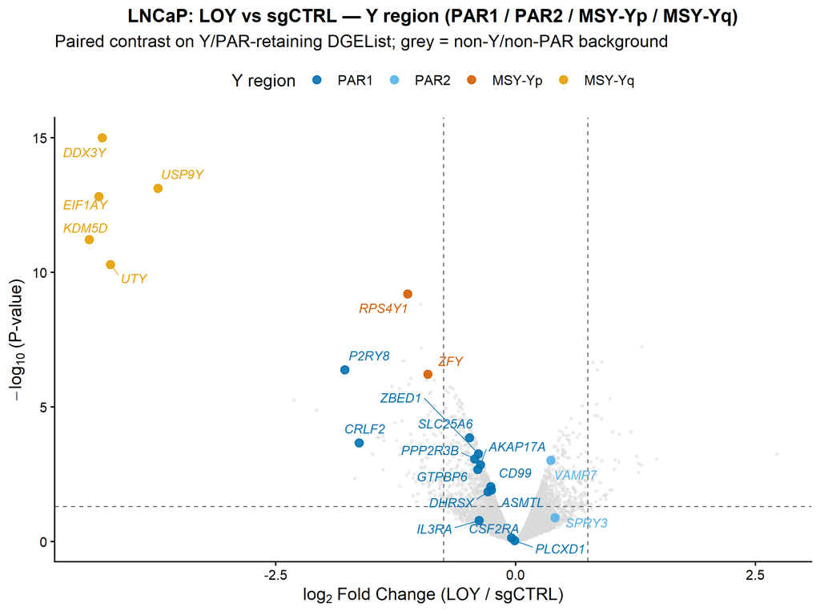

```
## Saved: volcano_LOY_v_sgCTRL_yregion.(png|pdf)  [8x6 in]
```

# 4. Differential Expression: LOY vs sgCTRL

Two designs are fit on `dge_lc` (chrY MSY genes removed, PAR genes retained, TMM recalculated — see §2.1.5 for the split policy): **paired** (treatment + passage) is the recommended primary analysis; **unpaired** is shown for reference. PAR genes get logFC + FDR like every other gene and appear in the volcanos below. Downstream GSEA in §5+ excludes PAR genes at the rank boundary via `prep_ranks_t()`. The Y-region landscape on a Y/PAR-retaining DGEList is in §3.5.

```
## Removing 7 chrY (MSY) genes
```

```
## DE working set: 6 samples (CTRL/LOY)
```

## Paired (treatment + passage)

Design: `~ 0 + treatment + passage`. Passage covariate absorbs per-passage drift before the `LOY - CTRL` contrast.

```
## Design columns: CTRL, LOY, passage13, passage14
```

```
##
## Paired DE — LOY vs sgCTRL: 13392 genes tested
```

```
##   FDR < 0.05:              193
```

```
##   FDR < 0.05 & |logFC| > 0.75:  64 (up: 15, down: 49)
```

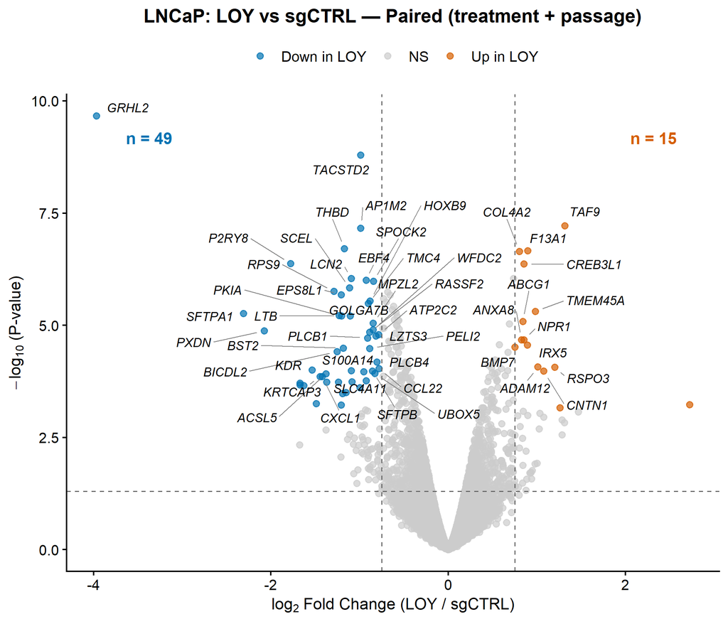

```
## Saved: volcano_LOY_v_sgCTRL_paired.(png|pdf)  [7x6 in]
```

## Unpaired (treatment only)

Design: `~ 0 + treatment`. Passage drift not modeled — reference for what the statistics look like without the covariate.

```
## Design columns: CTRL, LOY
```

```
##
## Unpaired DE — LOY vs sgCTRL: 13392 genes tested
```

```
##   FDR < 0.05:              1
```

```
##   FDR < 0.05 & |logFC| > 0.75:  1 (up: 0, down: 1)
```

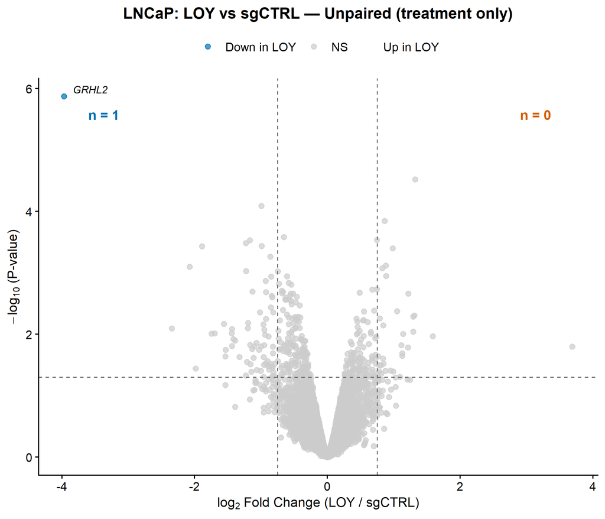

```
## Saved: volcano_LOY_v_sgCTRL_unpaired.(png|pdf)  [7x6 in]
```

# 5. GSEA (Basic Collections)

## 5.1 Setup: ranks + basic pathways

```
## Loading basic MSigDB collections...
```

```
##   hallmark: 50 gene sets
##   reactome: 1787 gene sets
##   kegg: 186 gene sets
##   go_bp: 7583 gene sets
```

## 5.2 Build ranks (RPS/RPL filtered)

```
## Ranked gene list: 13376 genes
```

```
## Removing 90 ribosomal protein genes (RPS/RPL)
```

```
## After RPS/RPL filter: 13286 genes
```

## 5.3 Run fgsea and save

```
## Running fgsea (basic collections) for LOY vs sgCTRL...
```

```
##   Running hallmark (50 gene sets)...
##   Running reactome (1787 gene sets)...
##   Running kegg (186 gene sets)...
##   Running go_bp (7583 gene sets)...
```

## 5.4 Summary

LOY vs sgCTRL — Significant pathways by collection

| collection | total | sig_up | sig_down |
| --- | --- | --- | --- |
| go_bp | 3442 | 79 | 145 |
| hallmark | 50 | 8 | 13 |
| kegg | 155 | 3 | 1 |
| reactome | 971 | 10 | 13 |

## 5.5 Publication dotplot

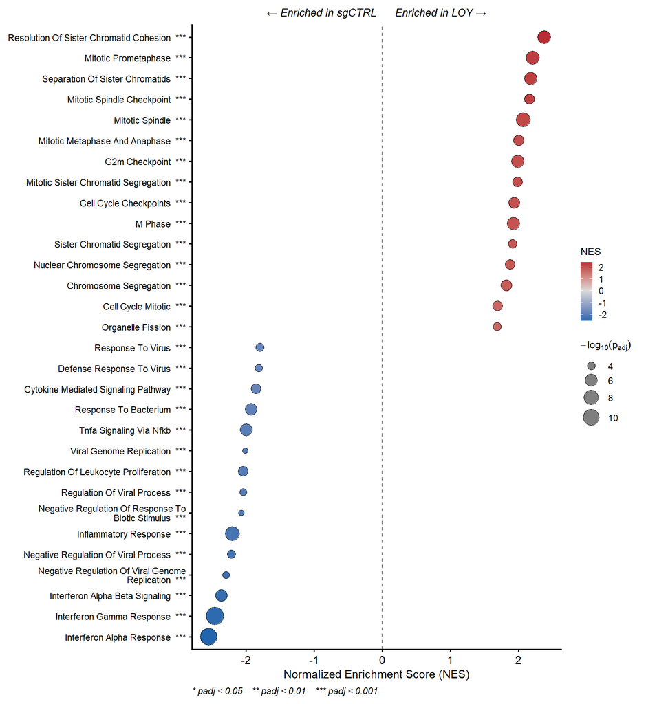

```
## Saved: gsea_dotplot_basic.(png|pdf)  [5.5x6 in]
```

## 5.6 Top Hallmark enrichment plots

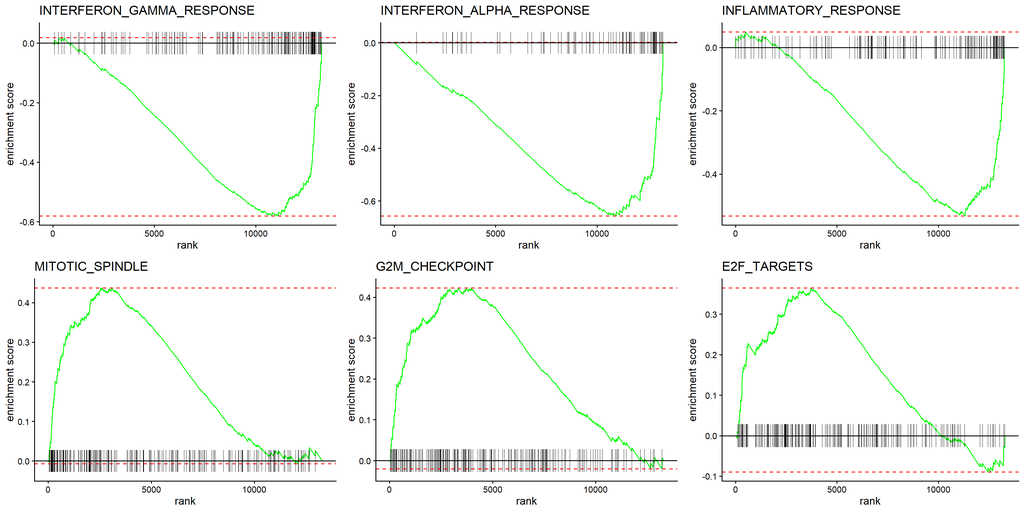

```
## Saved: gsea_enrichment_top_hallmark.(png|pdf)  [12x6 in]
```

# 6. GSEA (Expanded: +CGP, +CP subsets)

## 6.1 Load expanded collections

```
## Loading expanded MSigDB collections...
```

```
##   hallmark: 50 gene sets
##   c2_all: 7561 gene sets
##   cgp: 3538 gene sets
##   cp: 19 gene sets
##   cp_biocarta: 292 gene sets
##   cp_kegg_med: 658 gene sets
##   cp_pid: 196 gene sets
##   cp_reactome: 1787 gene sets
##   cp_wikipath: 885 gene sets
##   cp_kegg_leg: 186 gene sets
```

## 6.2 Run expanded fgsea

```
## Running fgsea (expanded) for LOY vs sgCTRL...
```

```
##   Running hallmark (50 gene sets)...
##   Running c2_all (7561 gene sets)...
##   Running cgp (3538 gene sets)...
##   Running cp (19 gene sets)...
##   Running cp_biocarta (292 gene sets)...
##   Running cp_kegg_med (658 gene sets)...
##   Running cp_pid (196 gene sets)...
##   Running cp_reactome (1787 gene sets)...
##   Running cp_wikipath (885 gene sets)...
##   Running cp_kegg_leg (186 gene sets)...
```

## 6.3 Expanded summary

LOY vs sgCTRL (expanded) — Significant pathways by collection

| collection | total | sig_up | sig_down |
| --- | --- | --- | --- |
| c2_all | 4673 | 209 | 245 |
| cgp | 2537 | 196 | 245 |
| cp | 13 | 0 | 0 |
| cp_biocarta | 104 | 0 | 0 |
| cp_kegg_leg | 155 | 3 | 1 |
| cp_kegg_med | 186 | 0 | 0 |
| cp_pid | 175 | 1 | 0 |
| cp_reactome | 971 | 11 | 15 |
| cp_wikipath | 532 | 4 | 9 |
| hallmark | 50 | 8 | 13 |

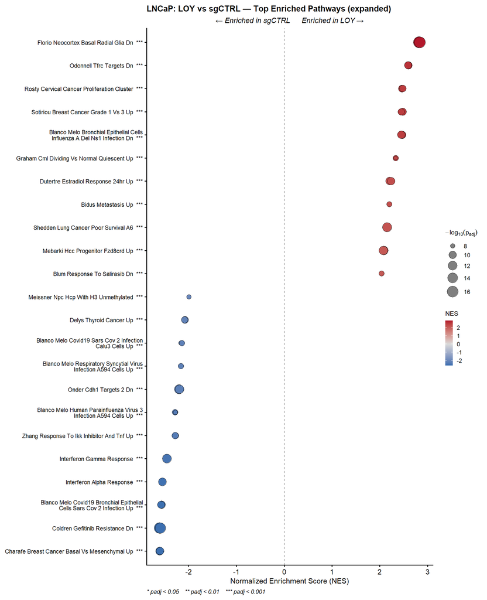

```
## Saved: gsea_dotplot_expanded.(png|pdf)  [6.5x8 in]
```

## 6.5 CGP-only dotplot

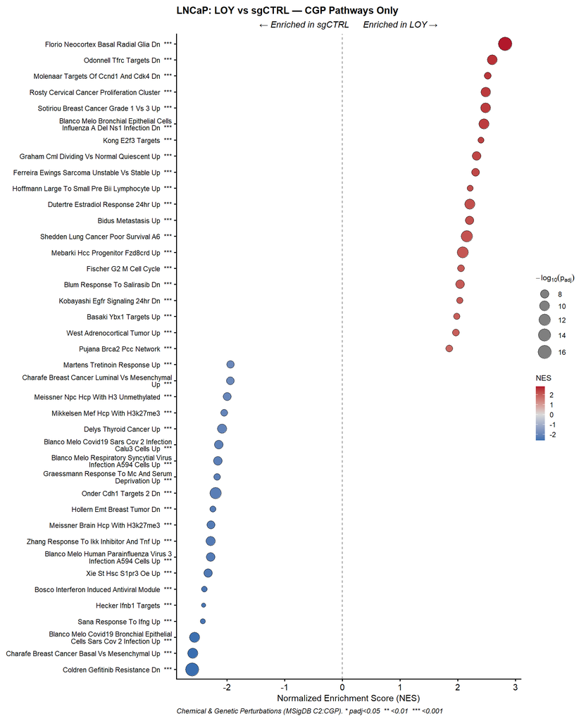

```
## Saved: gsea_dotplot_cgp.(png|pdf)  [6.5x8 in]
```

```
##
## Top 15 CGP pathways (by p-value):
```

LOY vs sgCTRL — Top 15 CGP pathways

| pathway | NES | pval | padj | size |
| --- | --- | --- | --- | --- |
| FLORIO_NEOCORTEX_BASAL_RADIAL_GLIA_DN | 2.822627 | 0 | 0 | 158 |
| COLDREN_GEFITINIB_RESISTANCE_DN | -2.603453 | 0 | 0 | 188 |
| SHEDDEN_LUNG_CANCER_POOR_SURVIVAL_A6 | 2.157496 | 0 | 0 | 413 |
| ONDER_CDH1_TARGETS_2_DN | -2.195997 | 0 | 0 | 369 |
| MEBARKI_HCC_PROGENITOR_FZD8CRD_UP | 2.089016 | 0 | 0 | 464 |
| BLANCO_MELO_COVID19_BRONCHIAL_EPITHELIAL_CELLS_SARS_COV_2_INFECTION_UP | -2.562251 | 0 | 0 | 99 |
| DUTERTRE_ESTRADIOL_RESPONSE_24HR_UP | 2.208653 | 0 | 0 | 294 |
| CHARAFE_BREAST_CANCER_BASAL_VS_MESENCHYMAL_UP | -2.596001 | 0 | 0 | 96 |
| BLANCO_MELO_BRONCHIAL_EPITHELIAL_CELLS_INFLUENZA_A_DEL_NS1_INFECTION_DN | 2.453998 | 0 | 0 | 157 |
| ODONNELL_TFRC_TARGETS_DN | 2.598093 | 0 | 0 | 104 |
| SOTIRIOU_BREAST_CANCER_GRADE_1_VS_3_UP | 2.482931 | 0 | 0 | 141 |
| ROSTY_CERVICAL_CANCER_PROLIFERATION_CLUSTER | 2.485963 | 0 | 0 | 133 |
| DELYS_THYROID_CANCER_UP | -2.081577 | 0 | 0 | 338 |
| ZHANG_RESPONSE_TO_IKK_INHIBITOR_AND_TNF_UP | -2.282765 | 0 | 0 | 186 |
| BLANCO_MELO_HUMAN_PARAINFLUENZA_VIRUS_3_INFECTION_A594_CELLS_UP | -2.282950 | 0 | 0 | 164 |

# 7. Chromatin / PRC2 Deep Dive

Polycomb / bivalent gene sets (MIKKELSEN H3K27me3 / H3K4me3+H3K27me3 bivalent sets, MEISSNER bivalent sets, BENPORATH PRC2 / SUZ12 targets, KAMMINGA EZH2 targets, PASINI SUZ12 targets) all converge on developmental genes that in normal cells carry H3K27me3 and/or bivalent H3K4me3+H3K27me3 promoter marks. Coordinated regulation of these sets points at a chromatin-state shift in LOY rather than scattered single-gene effects. The same query is applied to LNCaP here for direct comparison with the HT1080 and A549 results.

## 7.1 Chromatin pathway dotplot

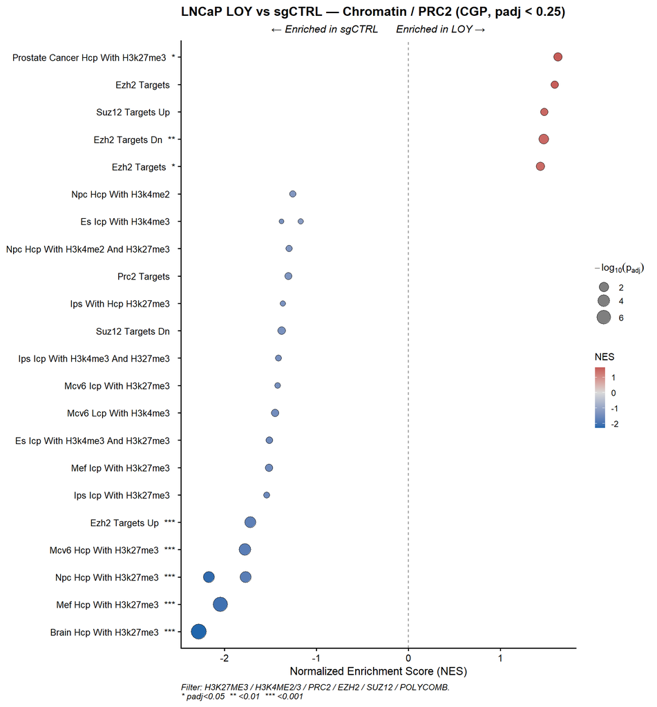

```
## Saved: gsea_dotplot_chromatin.(png|pdf)  [6.5x7 in]
##
## Chromatin pathways at padj < 0.05:
```

LNCaP LOY vs sgCTRL — significant chromatin pathways

| pathway | NES | pval | padj | size |
| --- | --- | --- | --- | --- |
| MEISSNER_BRAIN_HCP_WITH_H3K27ME3 | -2.279227 | 0.0000000 | 0.0000000 | 143 |
| MIKKELSEN_MEF_HCP_WITH_H3K27ME3 | -2.046114 | 0.0000000 | 0.0000001 | 248 |
| MIKKELSEN_MCV6_HCP_WITH_H3K27ME3 | -1.779518 | 0.0000069 | 0.0001630 | 214 |
| MEISSNER_NPC_HCP_WITH_H3K27ME3 | -2.170142 | 0.0000246 | 0.0004588 | 38 |
| MIKKELSEN_NPC_HCP_WITH_H3K27ME3 | -1.770041 | 0.0000252 | 0.0004674 | 162 |
| LU_EZH2_TARGETS_UP | -1.717675 | 0.0000332 | 0.0005846 | 241 |
| LU_EZH2_TARGETS_DN | 1.472796 | 0.0004406 | 0.0051991 | 338 |
| KONDO_PROSTATE_CANCER_HCP_WITH_H3K27ME3 | 1.627028 | 0.0040679 | 0.0300884 | 56 |
| KONDO_EZH2_TARGETS | 1.434916 | 0.0055334 | 0.0364905 | 156 |

## 7.2 Enrichment curves for top chromatin pathways

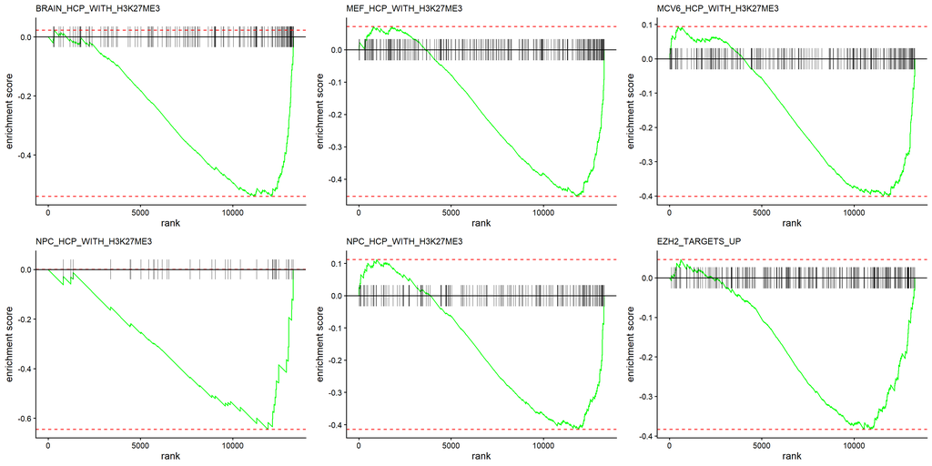

```
## Saved: gsea_enrichment_chromatin.(png|pdf)  [12x6 in]
```

## 7.3 H3K27me3 target gene volcano

Highlight `MIKKELSEN_MEF_HCP_WITH_H3K27ME3` member genes (bivalent-promoter developmental regulators carrying H3K27me3 in MEFs) on the full DE volcano.

```
## H3K27me3 set genes in DE: 248
##   nom. p < 0.05 & up:   11
##   nom. p < 0.05 & down: 38
```

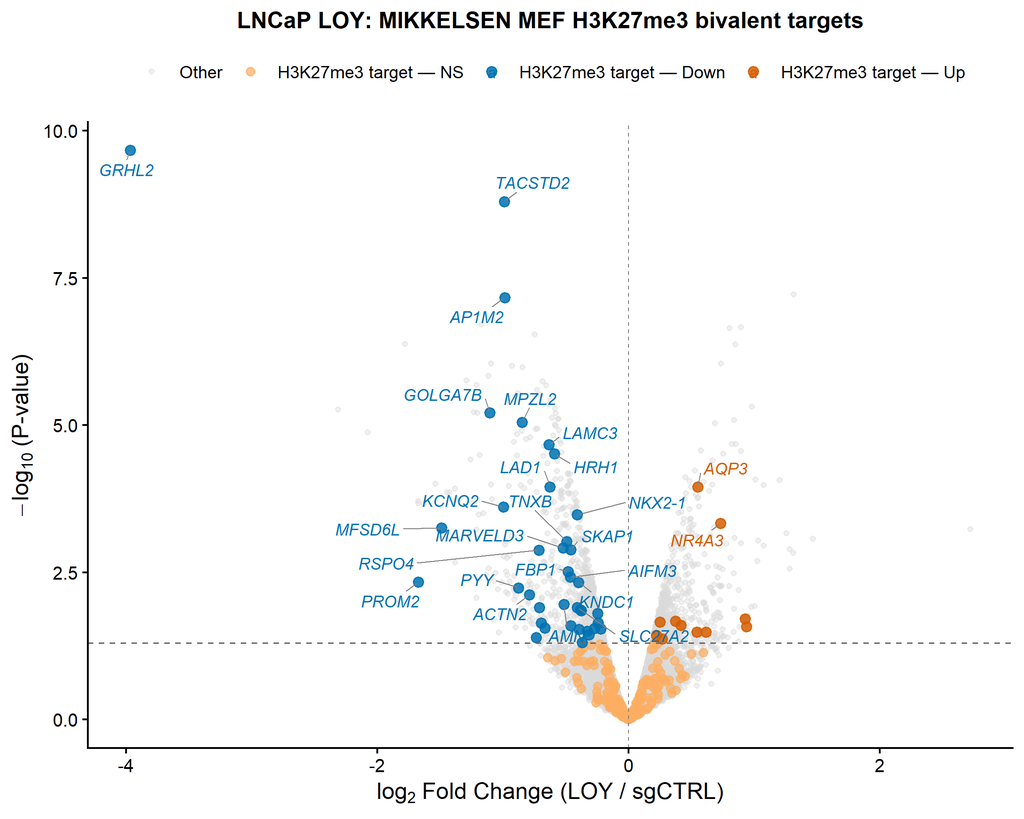

```
## Saved: volcano_h3k27me3_targets.(png|pdf)  [7.5x6 in]
```

# 8. AR / PI3K Signalling & the Cell-Cycle Paradox

**Working hypothesis.** LNCaP carries an **AR T878A** ligand-binding-domain mutation (constitutively active, broadly responsive androgen receptor) and is **PTEN-null** (biallelic deletion → constitutive PI3K/AKT/mTORC1 output). The proliferative ceiling is therefore set upstream by two saturating drivers (AR signalling and PI3K/AKT). In a cell already running both axes at near-saturation, a further LOY-induced bump in cell-cycle transcription may hit a ceiling downstream — receptor-level / metabolic / DNA-replication bottlenecks cap actual proliferation, while transcription still “writes the order” at E2F / MYC. This section unpacks the transcriptional side of that story alongside the AR/PI3K pathways themselves.

## 8.1 AR / PI3K / cell-cycle pathway dotplot

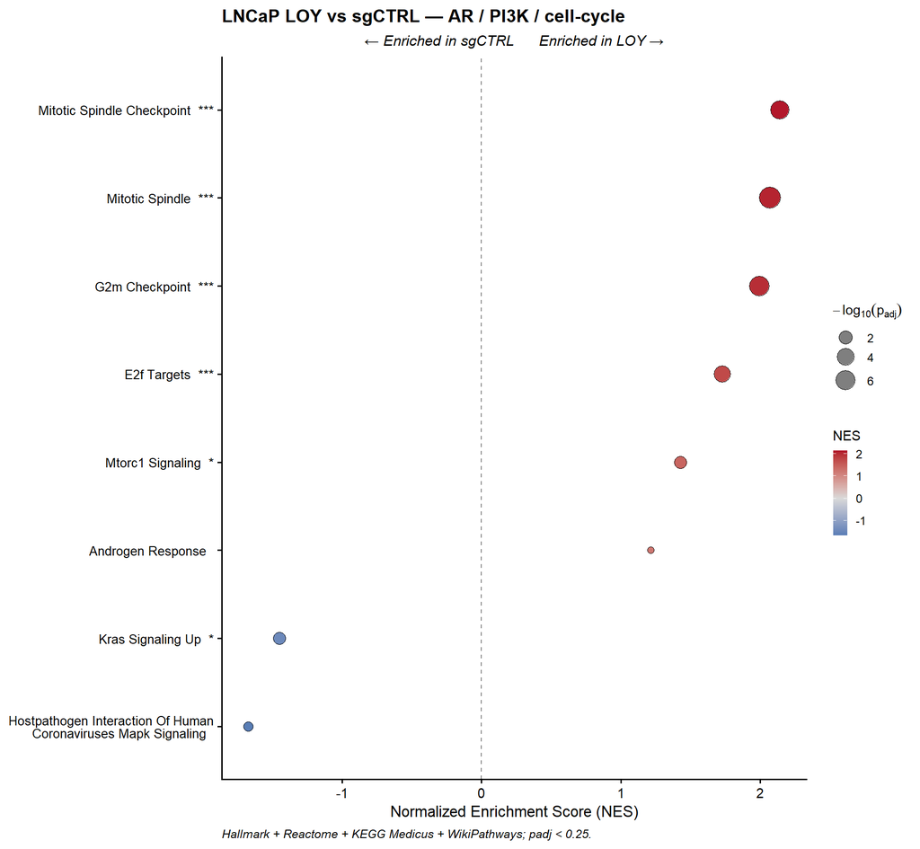

```
## Saved: gsea_dotplot_ar_pi3k_cellcycle.(png|pdf)  [6.5x6 in]
```

## 8.2 Enrichment curves: AR + PI3K/mTOR + cell cycle

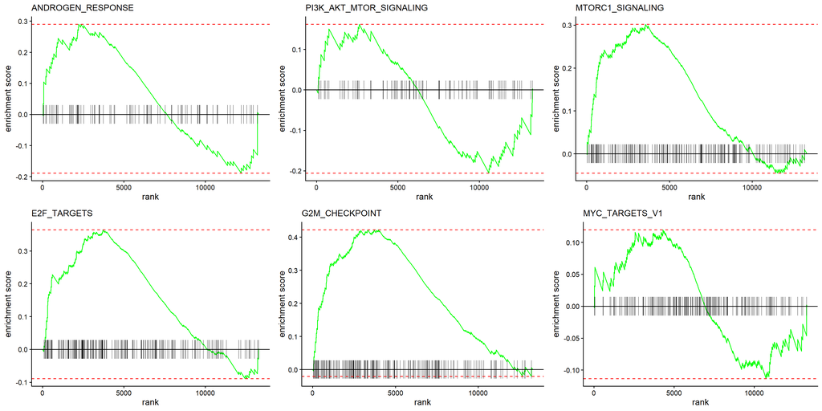

```
## Saved: gsea_enrichment_ar_pi3k_cellcycle.(png|pdf)  [12x6 in]
```

## 8.3 Cell-cycle gene overlay on volcano

Highlight Hallmark **E2F_TARGETS** member genes on the full DE volcano — shows whether the cell-cycle enrichment comes from many small coordinated shifts (“lots of small nudges, not a few big hits”) or a handful of outliers.

```
## E2F_TARGETS genes in DE: 194
##   nom. p<0.05 & up:   20
##   nom. p<0.05 & down: 7
```

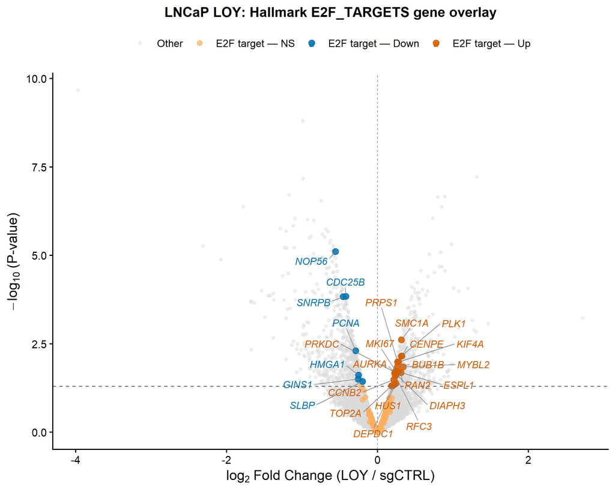

```
## Saved: volcano_e2f_targets.(png|pdf)  [7.5x6 in]
```

## 8.4 Expression of AR / PI3K axis and key cell-cycle / proliferation genes

```
## Focus genes present in DGE: 13
```

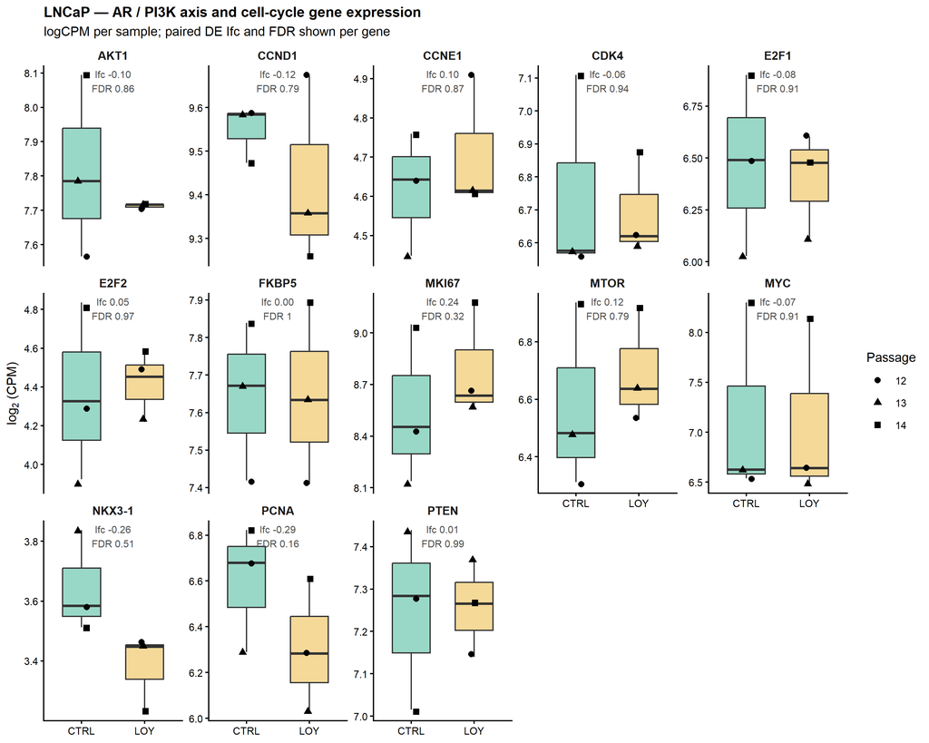

```
## Saved: ar_pi3k_cellcycle_boxplots.(png|pdf)  [10x8 in]
```

# 9. TF Regulon Activity (DoRothEA + decoupleR)

Two orthogonal methods to infer which transcription factors drive the LOY-vs-sgCTRL transcriptional program:

1. **DoRothEA + fgsea** — regulon-enrichment of MoR-weighted t-stats.
2. **decoupleR ULM (CollecTRI network)** — univariate linear model applied sample-by-sample (heatmap) and on the contrast t-stats (bar/volcano/scatter).

Both methods use the paired-design DE (`de_loy_ctrl`) and the ribo-filtered t-stat ranks (`ranks_loy_ctrl`).

## 9.1 Load DoRothEA regulons

```
## Loaded 246 TF regulons (A/B/C)
```

```
## Regulon size range: 10 - 383 (median: 32)
```

## 9.2 Run fgsea on MoR-weighted ranks

```
## Significant TFs (padj < 0.05): 13
```

## 9.3 Top TF results

```
##
## === Top 15 Activated TFs ===
```

| pathway | NES | padj | size |
| --- | --- | --- | --- |
| SOX2 | 1.702 | 0.008 | 169 |
| ZEB1 | 1.923 | 0.008 | 55 |
| ONECUT1 | 1.832 | 0.037 | 33 |
| NR1H3 | 1.901 | 0.040 | 10 |
| SREBF1 | 1.872 | 0.044 | 19 |
| TCF12 | 1.774 | 0.044 | 38 |

```
##
## === Top 15 Repressed TFs ===
```

| pathway | NES | padj | size |
| --- | --- | --- | --- |
| NFKB1 | -2.159 | 0.000 | 101 |
| STAT1 | -1.801 | 0.000 | 228 |
| STAT2 | -2.193 | 0.001 | 24 |
| RELB | -1.912 | 0.008 | 8 |
| FOXP1 | -1.709 | 0.022 | 141 |
| RELA | -1.666 | 0.037 | 90 |
| SP1 | -1.509 | 0.040 | 212 |

## 9.4 TF activity volcano

[figure not shown]

```
## Saved: tf_volcano_LOY_v_sgCTRL.(png|pdf)  [6x5 in]
```

## 9.5 TF activity dotplot

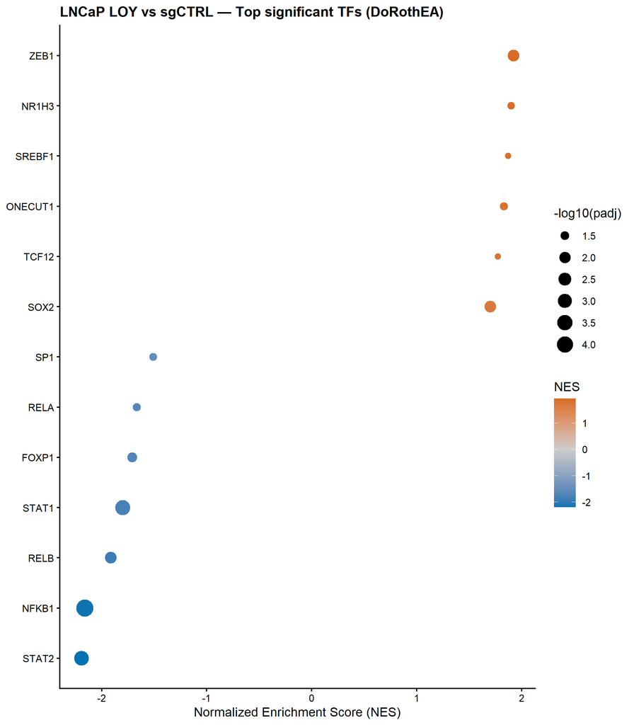

```
## Saved: tf_dotplot_LOY_v_sgCTRL.(png|pdf)  [7x8 in]
```

## 9.6 TF enrichment curves (top 3 activated + top 3 repressed)

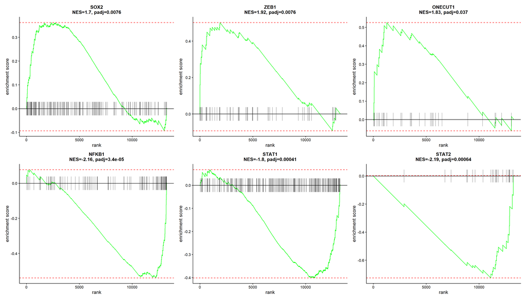

```
## Saved: tf_enrichment_top_LOY_v_sgCTRL.(png|pdf)  [14x8 in]
```

## 9.7 TF regulon overlay on DE volcano (top 6)

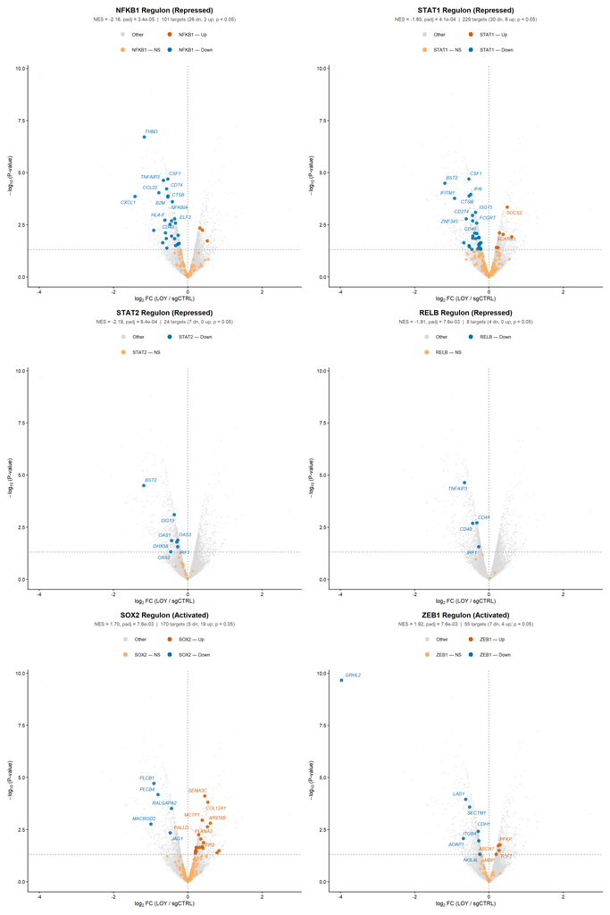

```
## Saved: tf_regulon_targets_LOY_v_sgCTRL.(png|pdf)  [12x18 in]
```

## 9.8 decoupleR — CollecTRI network

```
## CollecTRI network: 43159 interactions, 1186 TFs, 6686 targets
```

## 9.9 Sample-level TF activity (ULM)

```
## Sample-level ULM: 638 TFs × 6 samples
```

## 9.10 Sample-level TF activity heatmap (top variable)

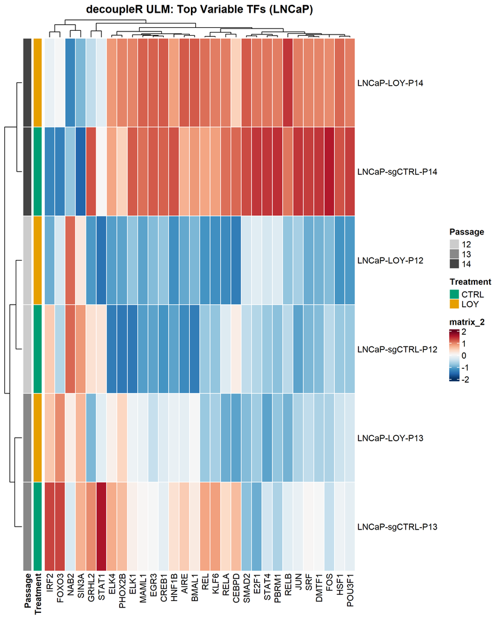

[figure not shown]

[figure not shown]

```
## Saved: decouple_TF_heatmap_LOY_v_sgCTRL.(png|pdf) [8x10 in]
```

## 9.11 Contrast-level TF activity (ULM on paired t-stats)

```
## Contrast-level ULM (CollecTRI): 638 TFs scored
```

```
## TRRUST v2 network: 7848 interactions, 742 TFs
```

```
## Contrast-level ULM (TRRUST): 236 TFs scored
```

## 9.12 TF activity bar plot

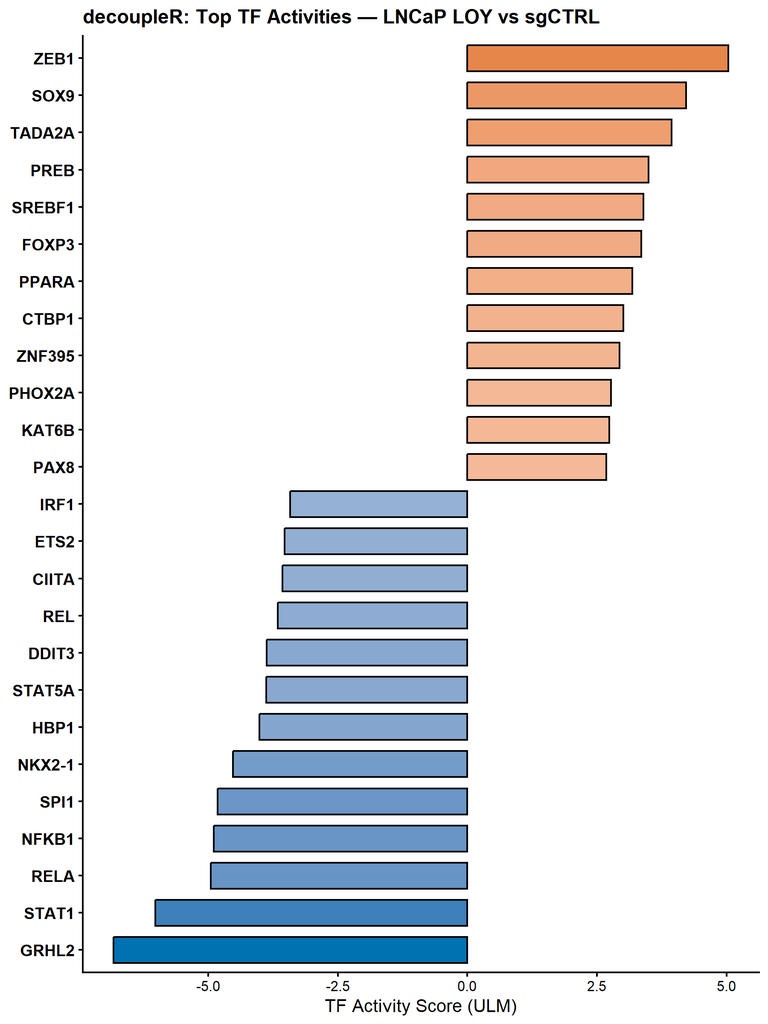

```
## Saved: decouple_TF_barplot_LOY_v_sgCTRL.(png|pdf)  [6x8 in]
```

## 9.13 Contrast-level TF volcano (decoupleR)

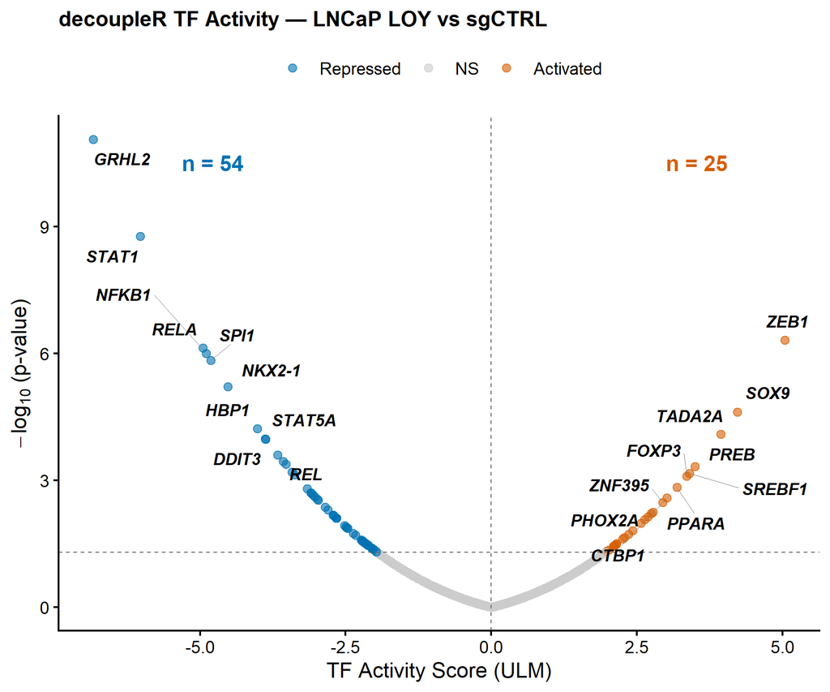

```
## Saved: decouple_TF_volcano_LOY_v_sgCTRL.(png|pdf)  [6x5 in]
```

## 9.14 Target gene scatter for top TFs (decoupleR)

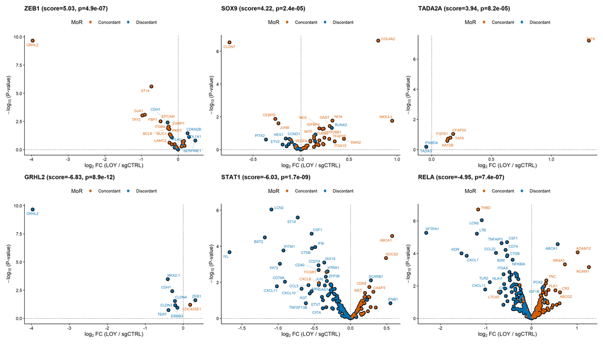

```
## Saved: decouple_TF_target_scatter_LOY_v_sgCTRL.(png|pdf)  [14x8 in]
```

## 9.15 Save decoupleR results

```
## decoupleR results saved to: A:/Dropbox/LOY_paralogs/projects/github/loy-synthetic-lethality/analysis/02_rnaseq/LNCaP/TF_analysis
```

**Interpretation.** The DoRothEA fgsea and decoupleR ULM analyses both infer TF activity from the coordinated regulation of each TF’s downstream targets — not from the TF’s own mRNA level. Agreement between the two methods on a TF (e.g., same direction in both volcanos) is the strongest evidence that the TF’s activity is altered in LOY. Differences can reflect (i) method weighting, (ii) regulon source (DoRothEA pancancer vs CollecTRI), or (iii) which targets were measured in this dataset.

# 10. Top-DEG Expression Boxplots

Per-sample logCPM for the strongest individual differentially-expressed genes (paired DE, Y-chr removed) — the individual-gene complement to the GSEA pathway view.

```
## Top up   (FDR<0.05 & lfc>0.75):  15 genes
```

```
## Top down (FDR<0.05 & lfc<-0.75): 20 genes
```

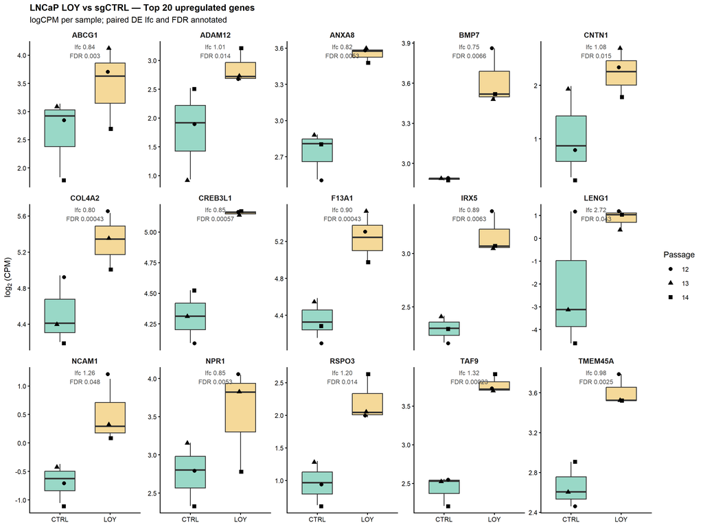

```
## Saved: boxplots_top20_up.(png|pdf)  [12x9 in]
```

## Top 20 Down in LOY

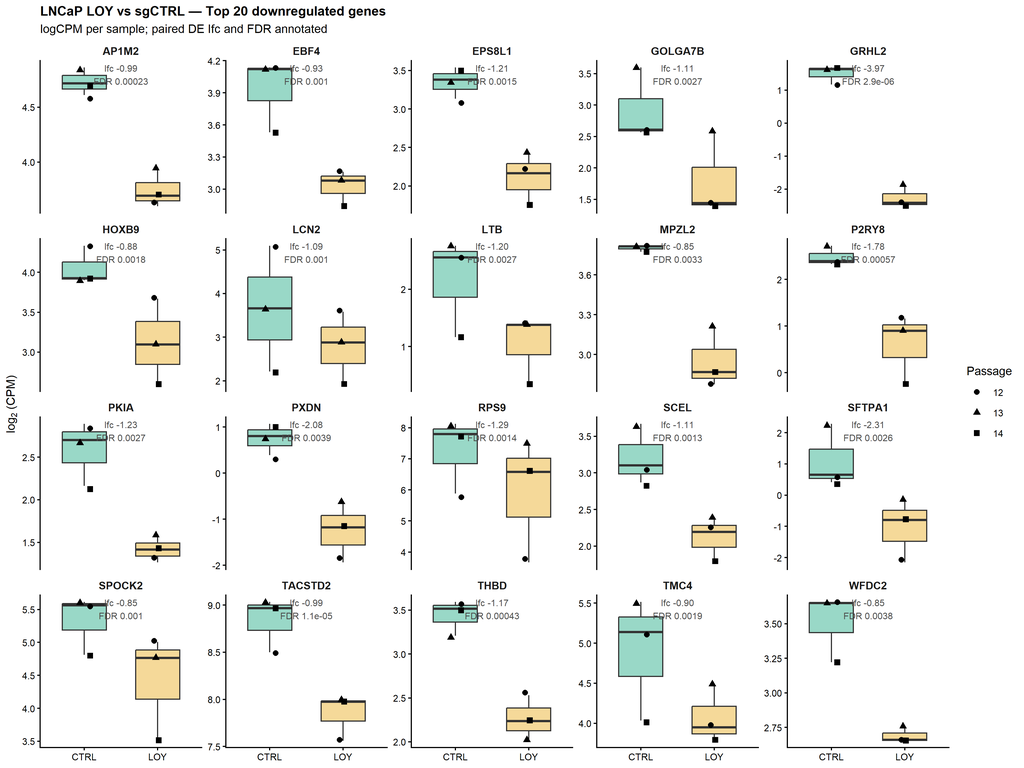

```
## Saved: boxplots_top20_down.(png|pdf)  [12x9 in]
```

# 11. msVIPER master-regulator analysis

Master-regulator inference via **msVIPER** (Alvarez et al., 2016) on the canonical LOY-vs-sgCTRL contrast. Two regulon sources are run side-by-side:

1. **CollecTRI** (HGNC-keyed) — the same human regulome decoupleR uses (§9).
2. **TCGA-PRAD ARACNe** (Entrez-keyed; `aracne.networks::regulonprad`) — tissue-matched to LNCaP (prostate adenocarcinoma).

Point estimates only (no bootstrap, shadow, or synergy) to keep render time manageable. Outputs feed the cross-method consistency analysis in §12.

## 11.1 Regulons + helpers

```
## CollecTRI regulon: 1186 TFs (median target size 9)
```

```
## TCGA-PRAD ARACNe regulon (relabeled TF names to HGNC; targets remain Entrez): 4085 TFs (median target size 44)
```

```
## TRRUST v2 regulon: 742 TFs (median target size 3)
```

```
## MSigDB C3:TFT:GTRD regulon: 505 TFs (median target size 288)
```

```
## HGNC -> Entrez map: 13399 entries
```

## 11.2 LOY vs sgCTRL — canonical

### CollecTRI

```
## msVIPER CollecTRI (LOY vs sgCTRL): 252 TFs, 16 at FDR<0.05
```

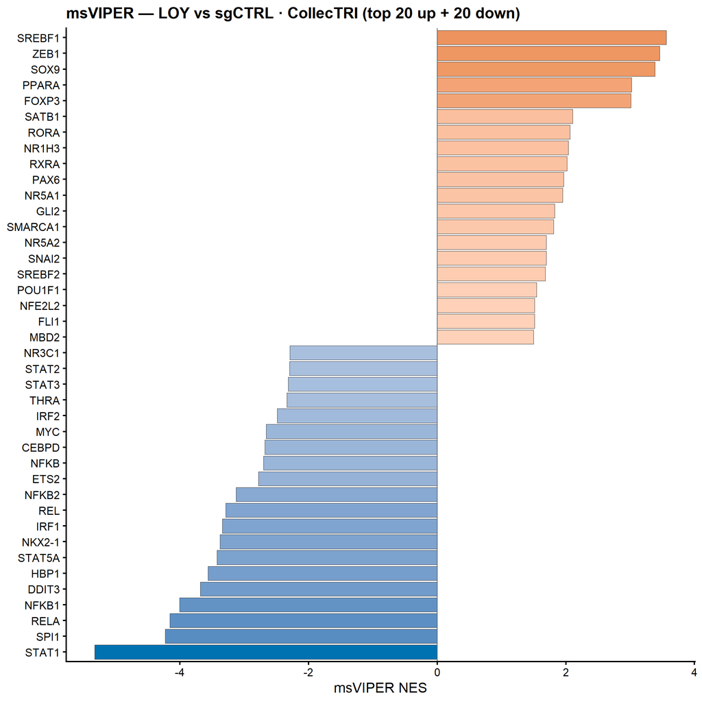

```
## Saved: msviper_bar_LOY_v_sgCTRL_collectri.(png|pdf)  [7x8 in]
```